# DATA 622 Assignment 4

Philip Tanofsky

4/23/2021

```r
# Import required R libraries
#library(vcd)
library(kernlab)
library(caret)
#library(MASS)
#library(ggplot2)
#library(mvtnorm)
#library(e1071)
#library(klaR)
#library(pROC)
#library(corrplot)
theme_set(theme_classic())

library(tidyverse)
library(tidymodels)
library(skimr)
#library(baguette)
#library(future)
#library(xgboost)
library(vip)
library(rpart.plot)
```

```r
# Read in loan approval csv
data <- read_csv("https://raw.githubusercontent.com/completegraph/DATA622_MACHINELEARNING/main/HW4/ADHD_data.csv")
names(data) <- make.names(names(data),unique = TRUE)

# Remove ADHD individual questions
#data <- data[, -c(5:22)]

# Remove MD individual questions
#data <- data[, -c(6:20)]

# Remove Psych.meds (too many NAs)
#data <- data[, -c(21)]

# Remove instances with missing data
#data <- na.omit(data)

#data <- data %>%
#  mutate_if(is.numeric, as.factor)

data$Suicide <- as.factor(data$Suicide)


data <- data %>% mutate(
             fSex = case_when( Sex == 1 ~ "M",
                               Sex == 2 ~ "F" ) ,
             fRace = case_when(
                  Race == 1 ~ "WH" ,
                  Race == 2 ~ "AF" ,
                  Race == 3 ~ "HI" ,
                  Race == 4 ~ "AS" ,
                  Race == 5 ~ "NA" ,
                  Race == 6 ~ "OT"
              ) ,
             fCO = case_when(Court.order == 0 ~ "No" ,
                             Court.order == 1 ~ "Yes") ,
             fHViol = case_when( Hx.of.Violence == 0 ~ "No",
                                 Hx.of.Violence == 1 ~ "Yes") ,
             fDCond = case_when( Disorderly.Conduct == 0 ~ "No" ,
                                 Disorderly.Conduct == 1 ~ "Yes") ,
             fSuicide  = case_when( Suicide == 0 ~ "No" ,
                                    Suicide == 1 ~ "Yes"),
             fMD.Q2  = case_when( MD.Q2 == 0 ~ "No" ,
                                  MD.Q2 == 1 ~ "Yes")
             )

data$fSex <- as.factor(data$fSex)
data$fSuicide <- as.factor(data$fSuicide)
data$fHViol <- as.factor(data$fHViol)
data$fAbuse <- factor(as.character(data$Abuse), levels=c("0","1","2","3","4","5","6","7"), ordered=TRUE)
data$ADHD.Q16 <- factor(as.character(data$ADHD.Q16), levels=c("0","1","2","3","4"), ordered=TRUE)
#data$MD.Q3 <- factor(as.character(data$MD.Q3), levels=c("0","1","2","3"), ordered=TRUE)
data$fEducation <- factor(as.character(data$Education), levels=c("6","7","8","9","10","11","12","13","14","15","16","17","18","19"), ordered=TRUE)

data$MD.Q1.Count <- 0
data$MD.Q1.Count <- ifelse(data$MD.Q1a == 1, data$MD.Q1.Count+1, data$MD.Q1.Count)
data$MD.Q1.Count <- ifelse(data$MD.Q1b == 1, data$MD.Q1.Count+1, data$MD.Q1.Count)
data$MD.Q1.Count <- ifelse(data$MD.Q1c == 1, data$MD.Q1.Count+1, data$MD.Q1.Count)
data$MD.Q1.Count <- ifelse(data$MD.Q1d == 1, data$MD.Q1.Count+1, data$MD.Q1.Count)
data$MD.Q1.Count <- ifelse(data$MD.Q1e == 1, data$MD.Q1.Count+1, data$MD.Q1.Count)
data$MD.Q1.Count <- ifelse(data$MD.Q1f == 1, data$MD.Q1.Count+1, data$MD.Q1.Count)
data$MD.Q1.Count <- ifelse(data$MD.Q1g == 1, data$MD.Q1.Count+1, data$MD.Q1.Count)
data$MD.Q1.Count <- ifelse(data$MD.Q1h == 1, data$MD.Q1.Count+1, data$MD.Q1.Count)
data$MD.Q1.Count <- ifelse(data$MD.Q1i == 1, data$MD.Q1.Count+1, data$MD.Q1.Count)
data$MD.Q1.Count <- ifelse(data$MD.Q1j == 1, data$MD.Q1.Count+1, data$MD.Q1.Count)
data$MD.Q1.Count <- ifelse(data$MD.Q1k == 1, data$MD.Q1.Count+1, data$MD.Q1.Count)
data$MD.Q1.Count <- ifelse(data$MD.Q1L == 1, data$MD.Q1.Count+1, data$MD.Q1.Count)
data$MD.Q1.Count <- ifelse(data$MD.Q1m == 1, data$MD.Q1.Count+1, data$MD.Q1.Count)
#data$MD <- ifelse(data$MD.Q1.Count>= 7 & data$MD.Q2 == 1 & data$MD.Q3 >= 2, "Y", "N")
#data$MD <- as.factor(data$MD)

# Too many missing values, just remove the column
data$Psych.meds <- NULL

# Remove instances with missing data
data <- na.omit(data)

# Display skim summary
skim(data)
```

Data summary

| Name | data |
| --- | --- |
| Number of rows | 142 |
| Number of columns | 63 |
| _______________________ |  |
| Column type frequency: |  |
| character | 5 |
| factor | 7 |
| numeric | 51 |
| ________________________ |  |
| Group variables | None |

**Variable type: character**

| skim_variable | n_missing | complete_rate | min | max | empty | n_unique | whitespace |
| --- | --- | --- | --- | --- | --- | --- | --- |
| Initial | 0 | 1 | 2 | 3 | 0 | 91 | 0 |
| fRace | 0 | 1 | 2 | 2 | 0 | 4 | 0 |
| fCO | 0 | 1 | 2 | 3 | 0 | 2 | 0 |
| fDCond | 0 | 1 | 2 | 3 | 0 | 2 | 0 |
| fMD.Q2 | 0 | 1 | 2 | 3 | 0 | 2 | 0 |

**Variable type: factor**

| skim_variable | n_missing | complete_rate | ordered | n_unique | top_counts |
| --- | --- | --- | --- | --- | --- |
| ADHD.Q16 | 0 | 1 | TRUE | 5 | 1: 39, 2: 33, 0: 31, 4: 24 |
| Suicide | 0 | 1 | FALSE | 2 | 0: 97, 1: 45 |
| fSex | 0 | 1 | FALSE | 2 | M: 77, F: 65 |
| fHViol | 0 | 1 | FALSE | 2 | No: 105, Yes: 37 |
| fSuicide | 0 | 1 | FALSE | 2 | No: 97, Yes: 45 |
| fAbuse | 0 | 1 | TRUE | 8 | 0: 90, 2: 19, 1: 8, 5: 7 |
| fEducation | 0 | 1 | TRUE | 14 | 12: 55, 11: 21, 14: 14, 9: 12 |

**Variable type: numeric**

| skim_variable | n_missing | complete_rate | mean | sd | p0 | p25 | p50 | p75 | p100 | hist |
| --- | --- | --- | --- | --- | --- | --- | --- | --- | --- | --- |
| Age | 0 | 1 | 39.54 | 11.19 | 18 | 28.50 | 41.0 | 49 | 61 | ▆▅▅▇▃ |
| Sex | 0 | 1 | 1.46 | 0.50 | 1 | 1.00 | 1.0 | 2 | 2 | ▇▁▁▁▇ |
| Race | 0 | 1 | 1.61 | 0.63 | 1 | 1.00 | 2.0 | 2 | 6 | ▇▁▁▁▁ |
| ADHD.Q1 | 0 | 1 | 1.73 | 1.29 | 0 | 1.00 | 2.0 | 3 | 4 | ▆▇▇▆▃ |
| ADHD.Q2 | 0 | 1 | 1.91 | 1.25 | 0 | 1.00 | 2.0 | 3 | 4 | ▅▇▇▆▃ |
| ADHD.Q3 | 0 | 1 | 1.90 | 1.27 | 0 | 1.00 | 2.0 | 3 | 4 | ▅▇▇▅▅ |
| ADHD.Q4 | 0 | 1 | 2.10 | 1.36 | 0 | 1.00 | 2.0 | 3 | 4 | ▅▆▇▅▆ |
| ADHD.Q5 | 0 | 1 | 2.30 | 1.45 | 0 | 1.00 | 3.0 | 4 | 5 | ▇▅▇▇▁ |
| ADHD.Q6 | 0 | 1 | 1.96 | 1.32 | 0 | 1.00 | 2.0 | 3 | 4 | ▆▅▇▇▃ |
| ADHD.Q7 | 0 | 1 | 1.89 | 1.21 | 0 | 1.00 | 2.0 | 3 | 4 | ▃▇▇▅▃ |
| ADHD.Q8 | 0 | 1 | 2.18 | 1.33 | 0 | 1.00 | 2.0 | 3 | 4 | ▃▇▆▇▆ |
| ADHD.Q9 | 0 | 1 | 1.94 | 1.36 | 0 | 1.00 | 2.0 | 3 | 4 | ▆▇▆▇▅ |
| ADHD.Q10 | 0 | 1 | 2.11 | 1.26 | 0 | 1.00 | 2.0 | 3 | 4 | ▂▇▇▅▆ |
| ADHD.Q11 | 0 | 1 | 2.27 | 1.24 | 0 | 1.00 | 2.0 | 3 | 4 | ▂▆▇▇▆ |
| ADHD.Q12 | 0 | 1 | 1.32 | 1.19 | 0 | 0.00 | 1.0 | 2 | 4 | ▇▇▅▂▂ |
| ADHD.Q13 | 0 | 1 | 2.43 | 1.23 | 0 | 2.00 | 3.0 | 3 | 4 | ▂▅▇▇▇ |
| ADHD.Q14 | 0 | 1 | 2.25 | 1.38 | 0 | 1.00 | 2.0 | 3 | 4 | ▅▅▆▇▇ |
| ADHD.Q15 | 0 | 1 | 1.68 | 1.42 | 0 | 0.00 | 2.0 | 3 | 4 | ▇▆▅▅▃ |
| ADHD.Q17 | 0 | 1 | 1.51 | 1.21 | 0 | 0.25 | 1.0 | 2 | 4 | ▇▇▇▅▂ |
| ADHD.Q18 | 0 | 1 | 1.55 | 1.31 | 0 | 0.00 | 1.0 | 2 | 4 | ▇▇▆▃▃ |
| ADHD.Total | 0 | 1 | 34.83 | 16.77 | 0 | 21.00 | 35.0 | 48 | 72 | ▃▆▇▇▂ |
| MD.Q1a | 0 | 1 | 0.55 | 0.50 | 0 | 0.00 | 1.0 | 1 | 1 | ▆▁▁▁▇ |
| MD.Q1b | 0 | 1 | 0.61 | 0.49 | 0 | 0.00 | 1.0 | 1 | 1 | ▅▁▁▁▇ |
| MD.Q1c | 0 | 1 | 0.55 | 0.50 | 0 | 0.00 | 1.0 | 1 | 1 | ▆▁▁▁▇ |
| MD.Q1d | 0 | 1 | 0.57 | 0.50 | 0 | 0.00 | 1.0 | 1 | 1 | ▆▁▁▁▇ |
| MD.Q1e | 0 | 1 | 0.60 | 0.49 | 0 | 0.00 | 1.0 | 1 | 1 | ▆▁▁▁▇ |
| MD.Q1f | 0 | 1 | 0.71 | 0.45 | 0 | 0.00 | 1.0 | 1 | 1 | ▃▁▁▁▇ |
| MD.Q1g | 0 | 1 | 0.73 | 0.45 | 0 | 0.00 | 1.0 | 1 | 1 | ▃▁▁▁▇ |
| MD.Q1h | 0 | 1 | 0.60 | 0.49 | 0 | 0.00 | 1.0 | 1 | 1 | ▆▁▁▁▇ |
| MD.Q1i | 0 | 1 | 0.62 | 0.49 | 0 | 0.00 | 1.0 | 1 | 1 | ▅▁▁▁▇ |
| MD.Q1j | 0 | 1 | 0.42 | 0.50 | 0 | 0.00 | 0.0 | 1 | 1 | ▇▁▁▁▆ |
| MD.Q1k | 0 | 1 | 0.49 | 0.50 | 0 | 0.00 | 0.0 | 1 | 1 | ▇▁▁▁▇ |
| MD.Q1L | 0 | 1 | 0.58 | 0.49 | 0 | 0.00 | 1.0 | 1 | 1 | ▆▁▁▁▇ |
| MD.Q1m | 0 | 1 | 0.50 | 0.50 | 0 | 0.00 | 0.5 | 1 | 1 | ▇▁▁▁▇ |
| MD.Q2 | 0 | 1 | 0.75 | 0.43 | 0 | 1.00 | 1.0 | 1 | 1 | ▂▁▁▁▇ |
| MD.Q3 | 0 | 1 | 2.01 | 1.06 | 0 | 1.00 | 2.0 | 3 | 3 | ▂▃▁▆▇ |
| MD.TOTAL | 0 | 1 | 10.30 | 4.71 | 0 | 7.00 | 11.0 | 14 | 17 | ▃▃▆▇▇ |
| Alcohol | 0 | 1 | 1.43 | 1.40 | 0 | 0.00 | 1.0 | 3 | 3 | ▇▂▁▁▇ |
| THC | 0 | 1 | 0.77 | 1.24 | 0 | 0.00 | 0.0 | 1 | 3 | ▇▁▁▁▂ |
| Cocaine | 0 | 1 | 1.09 | 1.39 | 0 | 0.00 | 0.0 | 3 | 3 | ▇▁▁▁▅ |
| Stimulants | 0 | 1 | 0.15 | 0.58 | 0 | 0.00 | 0.0 | 0 | 3 | ▇▁▁▁▁ |
| Sedative.hypnotics | 0 | 1 | 0.14 | 0.59 | 0 | 0.00 | 0.0 | 0 | 3 | ▇▁▁▁▁ |
| Opioids | 0 | 1 | 0.42 | 1.03 | 0 | 0.00 | 0.0 | 0 | 3 | ▇▁▁▁▁ |
| Court.order | 0 | 1 | 0.08 | 0.27 | 0 | 0.00 | 0.0 | 0 | 1 | ▇▁▁▁▁ |
| Education | 0 | 1 | 11.94 | 2.17 | 6 | 11.00 | 12.0 | 13 | 19 | ▁▅▇▂▁ |
| Hx.of.Violence | 0 | 1 | 0.26 | 0.44 | 0 | 0.00 | 0.0 | 1 | 1 | ▇▁▁▁▃ |
| Disorderly.Conduct | 0 | 1 | 0.70 | 0.46 | 0 | 0.00 | 1.0 | 1 | 1 | ▃▁▁▁▇ |
| Abuse | 0 | 1 | 1.23 | 2.03 | 0 | 0.00 | 0.0 | 2 | 7 | ▇▂▁▁▁ |
| Non.subst.Dx | 0 | 1 | 0.46 | 0.69 | 0 | 0.00 | 0.0 | 1 | 2 | ▇▁▃▁▂ |
| Subst.Dx | 0 | 1 | 1.12 | 0.95 | 0 | 0.00 | 1.0 | 2 | 3 | ▆▇▁▅▂ |
| MD.Q1.Count | 0 | 1 | 7.53 | 3.92 | 0 | 4.00 | 8.0 | 11 | 13 | ▃▅▅▆▇ |

```r
ggplot(data, aes(x=data$Psych.meds, color=Suicide)) +
  geom_histogram(fill="black", alpha=0.5, position="dodge")
```

```r
data %>%
  group_by(Suicide) %>%
  mutate(count = n())
```

```
## # A tibble: 142 x 64
## # Groups:   Suicide [2]
##    Initial   Age   Sex  Race ADHD.Q1 ADHD.Q2 ADHD.Q3 ADHD.Q4 ADHD.Q5 ADHD.Q6
##    <chr>   <dbl> <dbl> <dbl>   <dbl>   <dbl>   <dbl>   <dbl>   <dbl>   <dbl>
##  1 JA         24     1     1       1       1       4       2       3       1
##  2 LA         48     2     1       3       3       4       4       5       2
##  3 MD         51     2     1       2       1       2       1       3       3
##  4 RD         43     1     1       3       3       2       2       4       3
##  5 RB         34     1     1       4       4       2       4       4       2
##  6 SB         39     2     1       2       3       1       4       3       2
##  7 PK         41     2     1       2       2       1       3       4       4
##  8 RJ         48     1     1       2       4       3       4       3       3
##  9 DJ         44     2     1       3       3       3       4       4       3
## 10 SH         27     2     1       2       3       4       4       4       3
## # … with 132 more rows, and 54 more variables: ADHD.Q7 <dbl>, ADHD.Q8 <dbl>,
## #   ADHD.Q9 <dbl>, ADHD.Q10 <dbl>, ADHD.Q11 <dbl>, ADHD.Q12 <dbl>,
## #   ADHD.Q13 <dbl>, ADHD.Q14 <dbl>, ADHD.Q15 <dbl>, ADHD.Q16 <ord>,
## #   ADHD.Q17 <dbl>, ADHD.Q18 <dbl>, ADHD.Total <dbl>, MD.Q1a <dbl>,
## #   MD.Q1b <dbl>, MD.Q1c <dbl>, MD.Q1d <dbl>, MD.Q1e <dbl>, MD.Q1f <dbl>,
## #   MD.Q1g <dbl>, MD.Q1h <dbl>, MD.Q1i <dbl>, MD.Q1j <dbl>, MD.Q1k <dbl>,
## #   MD.Q1L <dbl>, MD.Q1m <dbl>, MD.Q2 <dbl>, MD.Q3 <dbl>, MD.TOTAL <dbl>,
## #   Alcohol <dbl>, THC <dbl>, Cocaine <dbl>, Stimulants <dbl>,
## #   Sedative.hypnotics <dbl>, Opioids <dbl>, Court.order <dbl>,
## #   Education <dbl>, Hx.of.Violence <dbl>, Disorderly.Conduct <dbl>,
## #   Suicide <fct>, Abuse <dbl>, Non.subst.Dx <dbl>, Subst.Dx <dbl>, fSex <fct>,
## #   fRace <chr>, fCO <chr>, fHViol <fct>, fDCond <chr>, fSuicide <fct>,
## #   fMD.Q2 <chr>, fAbuse <ord>, fEducation <ord>, MD.Q1.Count <dbl>,
## #   count <int>
```

```r
# of the 142, Suicide Yes=45, Suicide No=97
```

http://www.rebeccabarter.com/blog/2020-03-25_machine_learning/

```r
# Split into training and test data
set.seed(1234)
# split the data into training (75%) and testing (25%)
data_split <- initial_split(data, prop = .75)
data_split
```

```
## <Analysis/Assess/Total>
## <107/35/142>
```

```r
data_train <- training(data_split)
data_test <- testing(data_split)
```

```r
# Create CV object from training data
data_cv <- vfold_cv(data_train, v=5, repeats=3)
#data_cv <- vfold_cv(data_train)
```

```r
# Recipe attempt v0 ... ignore for now
# Define the recipe
data_recipe <- recipe(Suicide ~ THC + Cocaine + Opioids, data = data) %>%
  step_normalize(all_numeric()) %>%
  step_knnimpute(all_predictors())
```

Age + Sex + Race + ADHD.Total + MD.TOTAL + Alcohol + THC + Cocaine + Stimulants + Sedative.hypnotics + Opioids + Court.order + Education + Hx.of.Violence + Disorderly.Conduct + Abuse + Non.subst.Dx + Subst.Dx

```r
# https://www.tidymodels.org/learn/work/tune-svm/
#data_recipe <- recipe(fSuicide ~ fSex + ADHD.Total + MD.TOTAL + fAbuse, data = data) %>%
# 69%
#data_recipe <- recipe(fSuicide ~ fSex + ADHD.Total + MD.Q1.Count + MD.Q2 + MD.Q3 + fAbuse, data = data) %>%
# 71%
#data_recipe <- recipe(fSuicide ~ fSex + MD.Q1.Count + MD.Q2 + MD.Q3 + fAbuse, data = data) %>%
# 0.7142857
#data_recipe <- recipe(fSuicide ~ fSex + MD.Q1.Count + fMD.Q2 + MD.Q3 + fAbuse + ADHD.Q16, data = data) %>%
# 0.6571429
#data_recipe <- recipe(fSuicide ~ fSex + MD.Q1.Count + fMD.Q2 + MD.Q3 + fAbuse, data = data) %>%
#0.6285714
#data_recipe <- recipe(fSuicide ~ fSex + MD.Q1.Count + MD.Q2 + MD.Q3 + fAbuse, data = data) %>%
#0.6285714
data_recipe <- recipe(fSuicide ~ fSex + MD.Q1.Count + MD.Q2 + MD.Q3 + fAbuse, data = data) %>%
  step_normalize(all_numeric(), -all_outcomes()) %>%
  step_dummy(all_nominal(), -all_outcomes())  %>%
  # Remove any zero variance predictors
  step_zv(all_predictors()) %>%
  # Remove any linear combinations
  step_lincomb(all_numeric())
```

From Alex: predictors for suicide ADHD, Mood, Abuse and seem to impact women more than men.

All predictors: Age + Sex + Race + ADHD.Total + MD.TOTAL + Alcohol + THC + Cocaine + Stimulants + Sedative.hypnotics + Opioids + Court.order + Education + Hx.of.Violence + Disorderly.Conduct + Abuse + Non.subst.Dx + Subst.Dx

```r
set.seed(1234)
data_rs <- bootstraps(data, times = 5)
```

```r
# Consider log-likelihood statistic
# using ROC curve for now
roc_vals <- metric_set(roc_auc, accuracy, kap)
```

```r
# Verbose turned off, save out-of-sample predictions is turned on
ctrl <- control_grid(verbose=F, save_pred=T)
```

```r
# SVM Model with Polynomial
svm_model <- svm_poly(cost = tune(),
                      degree = tune()) %>%
  set_engine("kernlab") %>%
  set_mode("classification") %>%
  translate()
```

```r
# SVM Model with Radial Basis Function
svm_model <- svm_rbf(cost = tune(),
                     rbf_sigma = tune()) %>%
  set_mode("classification") %>%
  set_engine("kernlab") %>%
  translate()
```

```r
# Generate formula
formula_res <- svm_model %>%
  tune_grid(data_recipe,
    resamples = data_cv,
    metrics = roc_vals,
    control = ctrl
  )

formula_res
```

```
## # Tuning results
## # 5-fold cross-validation repeated 3 times
## # A tibble: 15 x 6
##    splits       id      id2   .metrics         .notes         .predictions
##    <list>       <chr>   <chr> <list>           <list>         <list>
##  1 <split [85/… Repeat1 Fold1 <tibble[,6] [30… <tibble[,1] [… <tibble[,8] [220 …
##  2 <split [85/… Repeat1 Fold2 <tibble[,6] [30… <tibble[,1] [… <tibble[,8] [220 …
##  3 <split [86/… Repeat1 Fold3 <tibble[,6] [30… <tibble[,1] [… <tibble[,8] [210 …
##  4 <split [86/… Repeat1 Fold4 <tibble[,6] [30… <tibble[,1] [… <tibble[,8] [210 …
##  5 <split [86/… Repeat1 Fold5 <tibble[,6] [30… <tibble[,1] [… <tibble[,8] [210 …
##  6 <split [85/… Repeat2 Fold1 <tibble[,6] [30… <tibble[,1] [… <tibble[,8] [220 …
##  7 <split [85/… Repeat2 Fold2 <tibble[,6] [30… <tibble[,1] [… <tibble[,8] [220 …
##  8 <split [86/… Repeat2 Fold3 <tibble[,6] [30… <tibble[,1] [… <tibble[,8] [210 …
##  9 <split [86/… Repeat2 Fold4 <tibble[,6] [30… <tibble[,1] [… <tibble[,8] [210 …
## 10 <split [86/… Repeat2 Fold5 <tibble[,6] [30… <tibble[,1] [… <tibble[,8] [210 …
## 11 <split [85/… Repeat3 Fold1 <tibble[,6] [30… <tibble[,1] [… <tibble[,8] [220 …
## 12 <split [85/… Repeat3 Fold2 <tibble[,6] [30… <tibble[,1] [… <tibble[,8] [220 …
## 13 <split [86/… Repeat3 Fold3 <tibble[,6] [30… <tibble[,1] [… <tibble[,8] [210 …
## 14 <split [86/… Repeat3 Fold4 <tibble[,6] [30… <tibble[,1] [… <tibble[,8] [210 …
## 15 <split [86/… Repeat3 Fold5 <tibble[,6] [30… <tibble[,1] [… <tibble[,8] [210 …
```

Suicide ~ Age + Sex + Race + ADHD.Total + MD.TOTAL + Alcohol + THC + Cocaine + Stimulants + Sedative.hypnotics + Opioids + Court.order + Education + Hx.of.Violence + Disorderly.Conduct + Abuse + Non.subst.Dx + Subst.Dx

```r
# The .metrics column contains tibbles of the performance metrics for each tuning parameter combination
formula_res %>%
  select(.metrics) %>%
  slice(1) %>%
  pull(1)
```

```
## [[1]]
## # A tibble: 30 x 6
##        cost degree .metric  .estimator .estimate .config
##       <dbl>  <int> <chr>    <chr>          <dbl> <fct>
##  1  0.314        2 accuracy binary        0.5    Preprocessor1_Model01
##  2  0.314        2 kap      binary       -0.0522 Preprocessor1_Model01
##  3  0.314        2 roc_auc  binary        0.420  Preprocessor1_Model01
##  4  0.00465      2 accuracy binary        0.545  Preprocessor1_Model02
##  5  0.00465      2 kap      binary       -0.0377 Preprocessor1_Model02
##  6  0.00465      2 roc_auc  binary        0.509  Preprocessor1_Model02
##  7 10.9          3 accuracy binary        0.273  Preprocessor1_Model03
##  8 10.9          3 kap      binary       -0.419  Preprocessor1_Model03
##  9 10.9          3 roc_auc  binary        0.696  Preprocessor1_Model03
## 10  0.0233       3 accuracy binary        0.409  Preprocessor1_Model04
## # … with 20 more rows
```

```r
# Get final resampling estimates
estimates <- collect_metrics(formula_res)
estimates
```

```
## # A tibble: 30 x 8
##        cost degree .metric  .estimator  mean     n std_err .config
##       <dbl>  <int> <chr>    <chr>      <dbl> <int>   <dbl> <fct>
##  1  0.314        2 accuracy binary     0.702    15  0.0223 Preprocessor1_Model01
##  2  0.314        2 kap      binary     0.179    15  0.0622 Preprocessor1_Model01
##  3  0.314        2 roc_auc  binary     0.542    15  0.0451 Preprocessor1_Model01
##  4  0.00465      2 accuracy binary     0.748    15  0.0262 Preprocessor1_Model02
##  5  0.00465      2 kap      binary     0.219    15  0.0614 Preprocessor1_Model02
##  6  0.00465      2 roc_auc  binary     0.731    15  0.0253 Preprocessor1_Model02
##  7 10.9          3 accuracy binary     0.645    15  0.0321 Preprocessor1_Model03
##  8 10.9          3 kap      binary     0.102    15  0.0701 Preprocessor1_Model03
##  9 10.9          3 roc_auc  binary     0.494    15  0.0441 Preprocessor1_Model03
## 10  0.0233       3 accuracy binary     0.680    15  0.0271 Preprocessor1_Model04
## # … with 20 more rows
```

```r
# Display top combinations
show_best(formula_res, metric = "accuracy")
```

```
## # A tibble: 5 x 8
##      cost degree .metric  .estimator  mean     n std_err .config
##     <dbl>  <int> <chr>    <chr>      <dbl> <int>   <dbl> <fct>
## 1 0.00465      2 accuracy binary     0.748    15  0.0262 Preprocessor1_Model02
## 2 0.0192       2 accuracy binary     0.736    15  0.0212 Preprocessor1_Model10
## 3 0.00208      2 accuracy binary     0.723    15  0.0294 Preprocessor1_Model09
## 4 0.314        2 accuracy binary     0.702    15  0.0223 Preprocessor1_Model01
## 5 1.40         1 accuracy binary     0.689    15  0.0292 Preprocessor1_Model07
```

```r
# Execute with a recipe
set.seed(1234)
recipe_res <-svm_model %>%
  tune_grid(data_recipe,
    resamples = data_cv,
    metrics = roc_vals,
    control = ctrl
  )
recipe_res
```

```
## # Tuning results
## # 5-fold cross-validation repeated 3 times
## # A tibble: 15 x 6
##    splits       id      id2   .metrics         .notes         .predictions
##    <list>       <chr>   <chr> <list>           <list>         <list>
##  1 <split [85/… Repeat1 Fold1 <tibble[,6] [30… <tibble[,1] [… <tibble[,8] [220 …
##  2 <split [85/… Repeat1 Fold2 <tibble[,6] [30… <tibble[,1] [… <tibble[,8] [220 …
##  3 <split [86/… Repeat1 Fold3 <tibble[,6] [30… <tibble[,1] [… <tibble[,8] [210 …
##  4 <split [86/… Repeat1 Fold4 <tibble[,6] [30… <tibble[,1] [… <tibble[,8] [210 …
##  5 <split [86/… Repeat1 Fold5 <tibble[,6] [30… <tibble[,1] [… <tibble[,8] [210 …
##  6 <split [85/… Repeat2 Fold1 <tibble[,6] [30… <tibble[,1] [… <tibble[,8] [220 …
##  7 <split [85/… Repeat2 Fold2 <tibble[,6] [30… <tibble[,1] [… <tibble[,8] [220 …
##  8 <split [86/… Repeat2 Fold3 <tibble[,6] [30… <tibble[,1] [… <tibble[,8] [210 …
##  9 <split [86/… Repeat2 Fold4 <tibble[,6] [30… <tibble[,1] [… <tibble[,8] [210 …
## 10 <split [86/… Repeat2 Fold5 <tibble[,6] [30… <tibble[,1] [… <tibble[,8] [210 …
## 11 <split [85/… Repeat3 Fold1 <tibble[,6] [30… <tibble[,1] [… <tibble[,8] [220 …
## 12 <split [85/… Repeat3 Fold2 <tibble[,6] [30… <tibble[,1] [… <tibble[,8] [220 …
## 13 <split [86/… Repeat3 Fold3 <tibble[,6] [30… <tibble[,1] [… <tibble[,8] [210 …
## 14 <split [86/… Repeat3 Fold4 <tibble[,6] [30… <tibble[,1] [… <tibble[,8] [210 …
## 15 <split [86/… Repeat3 Fold5 <tibble[,6] [30… <tibble[,1] [… <tibble[,8] [210 …
```

```r
# Best setting
show_best(recipe_res, metric = "accuracy")
```

```
## # A tibble: 5 x 8
##       cost degree .metric  .estimator  mean     n std_err .config
##      <dbl>  <int> <chr>    <chr>      <dbl> <int>   <dbl> <fct>
## 1  0.00439      2 accuracy binary     0.739    15  0.0286 Preprocessor1_Model02
## 2  0.00126      2 accuracy binary     0.711    15  0.0299 Preprocessor1_Model01
## 3  0.0107       3 accuracy binary     0.698    15  0.0235 Preprocessor1_Model07
## 4 20.8          1 accuracy binary     0.689    15  0.0292 Preprocessor1_Model08
## 5  0.546        2 accuracy binary     0.686    15  0.0268 Preprocessor1_Model10
```

```r
# As save_pred = TRUE, we have kept the out-of-sample predictions for each sample
collect_predictions(recipe_res)
```

```
## # A tibble: 3,210 x 10
##    id      id2   .pred_No .pred_Yes  .row    cost degree .pred_class fSuicide
##    <chr>   <chr>    <dbl>     <dbl> <int>   <dbl>  <int> <fct>       <fct>
##  1 Repeat1 Fold1   0.764      0.236     2 0.00126      2 No          Yes
##  2 Repeat1 Fold1   0.534      0.466    12 0.00126      2 No          No
##  3 Repeat1 Fold1   0.0538     0.946    13 0.00126      2 Yes         No
##  4 Repeat1 Fold1   0.833      0.167    14 0.00126      2 No          No
##  5 Repeat1 Fold1   0.146      0.854    19 0.00126      2 Yes         Yes
##  6 Repeat1 Fold1   0.824      0.176    25 0.00126      2 No          Yes
##  7 Repeat1 Fold1   0.653      0.347    28 0.00126      2 No          Yes
##  8 Repeat1 Fold1   0.813      0.187    33 0.00126      2 No          No
##  9 Repeat1 Fold1   0.600      0.400    39 0.00126      2 No          No
## 10 Repeat1 Fold1   0.825      0.175    44 0.00126      2 No          Yes
## # … with 3,200 more rows, and 1 more variable: .config <fct>
```

```r
# Set the workflow
svm_wf <- workflow() %>%
  add_recipe(data_recipe) %>%
  add_model(svm_model)
```

```r
# Tune parameters
svm_grid <- expand.grid(mtry = c(3,4,5))

svm_tune_results <- svm_wf %>%
  tune_grid(resamples = data_cv,
            grid = svm_grid,
            metrics = metric_set(accuracy, roc_auc, kap)
            )

# Print results
svm_tune_results %>%
  collect_metrics()
```

```r
# Select best model based on roc_auc
best_svm <- recipe_res %>%
  select_best(metric = 'accuracy')

# view the best svm parameters
best_svm
```

```
## # A tibble: 1 x 3
##      cost degree .config
##     <dbl>  <int> <fct>
## 1 0.00439      2 Preprocessor1_Model02
```

```r
# finalize workflow
final_svm_wf <- svm_wf %>%
  finalize_workflow(best_svm)
```

```r
# fit the model
svm_wf_fit <- final_svm_wf %>%
  fit(data = data_train)
```

```r
svm_fit <- svm_wf_fit %>%
  pull_workflow_fit()

# Received error model-specific variable importance scores are currently not available for this type of model
#vip(svm_fit)
```

```r
# Received error: Not an rpart object
#rpart.plot(svm_fit$fit, roundint=FALSE)
```

```r
# train and evaluate
svm_last_fit <- final_svm_wf %>%
  last_fit(data_split)

svm_last_fit %>% collect_metrics()
```

```
## # A tibble: 2 x 4
##   .metric  .estimator .estimate .config
##   <chr>    <chr>          <dbl> <fct>
## 1 accuracy binary         0.714 Preprocessor1_Model1
## 2 roc_auc  binary         0.843 Preprocessor1_Model1
```

```r
svm_last_fit
```

```
## # Resampling results
## # Manual resampling
## # A tibble: 1 x 6
##   splits      id          .metrics       .notes       .predictions     .workflow
##   <list>      <chr>       <list>         <list>       <list>           <list>
## 1 <split [10… train/test… <tibble[,4] [… <tibble[,1]… <tibble[,6] [35… <workflo…
```

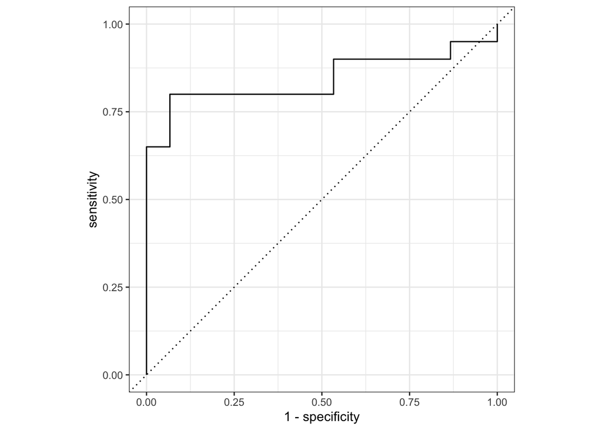

```r
svm_last_fit %>% collect_predictions() %>%
  roc_curve(truth = fSuicide, estimate = .pred_No) %>%
  autoplot()
```

```r
svm_predictions <- svm_last_fit %>% collect_predictions()

conf_mat(svm_predictions, truth = fSuicide, estimate = .pred_class)
```

```
##           Truth
## Prediction No Yes
##        No  18   8
##        Yes  2   7
```

```r
svm_predictions
```

```
## # A tibble: 35 x 7
##    id             .pred_No .pred_Yes  .row .pred_class fSuicide .config
##    <chr>             <dbl>     <dbl> <int> <fct>       <fct>    <fct>
##  1 train/test sp…    0.601     0.399     3 No          No       Preprocessor1_M…
##  2 train/test sp…    0.359     0.641     4 Yes         Yes      Preprocessor1_M…
##  3 train/test sp…    0.795     0.205     5 No          Yes      Preprocessor1_M…
##  4 train/test sp…    0.800     0.200    14 No          No       Preprocessor1_M…
##  5 train/test sp…    0.464     0.536    21 Yes         Yes      Preprocessor1_M…
##  6 train/test sp…    0.436     0.564    28 Yes         Yes      Preprocessor1_M…
##  7 train/test sp…    0.798     0.202    40 No          Yes      Preprocessor1_M…
##  8 train/test sp…    0.798     0.202    47 No          Yes      Preprocessor1_M…
##  9 train/test sp…    0.796     0.204    48 No          Yes      Preprocessor1_M…
## 10 train/test sp…    0.798     0.202    56 No          No       Preprocessor1_M…
## # … with 25 more rows
```

```r
mean(svm_predictions$.pred_class == svm_predictions$fSuicide)
```

```
## [1] 0.7142857
```

```r
svm_fit <- svm_wf %>%
  last_fit(data_split)

svm_fit
```

```r
test_perf <- svm_fit %>% collect_metrics()
test_perf
```

```r
test_predictions <- svm_fit %>% collect_predictions()
test_predictions
```

```r
test_predictions %>%
  conf_mat(truth = fSuicide, estimate = .pred_class)
```

```r
test_predictions %>%
  ggplot() +
  geom_density(aes(x = .pred_pos, fill = data),
               alpha = 0.5)
```

Results

With svm_poly, no tuning ## Truth ## Prediction 0 1 ## 0 20 11 ## 1 1 3

Results

with svm_rbf, with tuning ## Truth ## Prediction 0 1 ## 0 21 14 ## 1 0 0

With svm_poly, with tuning ## Prediction 0 1 ## 0 21 13 ## 1 0 1

With svm_poly, with tuning ## Truth ## Prediction 0 1 ## 0 18 11 ## 1 2 4

svm_rbf has never done anything but always predict No for suicide, no discernment

0.6904762 poly with BoxCox